# Has the Composition of Saudi Exports Shifted?

Abdullah Adel Al-Madhi

19 September 2026

# 1. Introduction

Saudi Arabia has been working to reduce its dependence on raw material exports as part of **Vision 2030**. The usual way to measure this is to look at total export values, but this approach has a problem: export values move with **oil prices** and **inflation**, so a rise in value does not necessarily mean a change in structure.

This report asks a different question:

> **Has the composition of Saudi exports shifted from raw materials toward manufactured goods between 2015 and 2026?**

To answer it we look at four things:

1. **What the composition looks like** and how it changed over the period.
2. **Whether the change is real growth** or only a side effect of falling oil exports.
3. **Whether the observed trend is statistically significant** rather than random fluctuation.
4. **Where the trend is heading** by 2030, and how much confidence we can place in that forecast.

# 2. The Data

The data comes from the **Statistical Database** of the General Authority for Statistics. It covers monthly export values from **January 2015 to May 2026**, which gives us **137 months**. Exports are classified by nature of materials into three categories:

1. **Manufactured** — finished industrial products, the highest value-added category.
2. **Semi-manufactured** — partially processed goods such as petrochemicals and refined products.
3. **Raw materials** — unprocessed exports, mainly crude oil.

These three categories are not arbitrary. They form a **value-added ladder**, and moving up this ladder is exactly what economic diversification means in practice.

## 2.1 Preparing the data

The original file was not ready for analysis and needed three steps:

1. The data came at the **transaction level**, meaning every single export operation had its own row. This gave **1,611,855 rows** in total, so we aggregated them by category and month. The result is **411 observations**, which is 137 months for each of the three categories.
2. The **date format** was not consistent. January was written as `YYYY / MM` while every other month used `M/D/YY`, so both formats had to be converted before the series could be ordered in time.
3. The **export values** were stored as text with thousand separators, so they had to be converted to numeric.

```r
library(ggplot2)     # Graphs
library(forecast)    # Arima & ggAcf & AutoPlot
library(tseries)     # ADF Test
library(patchwork)   # Merge two Graphs
library(sandwich)    # standard errors Correction
library(lmtest)      # coeftest
library(kableExtra)  # Summary tables

theme_set(theme_minimal(base_size = 11) +
          theme(plot.background  = element_rect(fill = "#fdf6e3", color = NA),
                panel.background = element_rect(fill = "#fdf6e3", color = NA),
                panel.grid.major = element_line(color = "#eadfc0", linewidth = 0.4),
                panel.grid.minor = element_blank()))
```

```r
# Clean file
monthly = read.csv("exports_clean.csv", fileEncoding = "UTF-8")

monthly$date     = as.Date(monthly$date)
monthly$category = trimws(monthly$category)

# Category labels: Arabic -> English
lab = c("مواد خام"  = "Raw",
        "نصف مصنعة" = "Semi-manufactured",
        "مصنعة"     = "Manufactured")

monthly$cat = unname(lab[monthly$category])

monthly$cat = factor(monthly$cat,
  levels = c("Raw", "Semi-manufactured", "Manufactured"))

stopifnot(!any(is.na(monthly$cat)))

monthly = monthly[order(monthly$date, monthly$cat), ]
rownames(monthly) = NULL

# Year, for the yearly comparisons
monthly$year = as.numeric(format(monthly$date, "%Y"))

# Share = category value / total for the same month
monthly$share = 100 * monthly$value / ave(monthly$value, monthly$date, FUN = sum)

# Monthly total, in SAR million
tot = tapply(monthly$value, monthly$date, sum)

man   = monthly[monthly$cat == "Manufactured", ]
man   = man[order(man$date), ]
man$t = 1:nrow(man)   # 1 = January 2015 ... 137 = May 2026

stopifnot(all(c("date", "cat", "year", "share", "value") %in% names(monthly)))

cat("rows:", nrow(monthly), "| months:", length(unique(monthly$date)), "\n")
```

```
## rows: 411 | months: 137
```

```r
cat("range:", format(range(monthly$date)), "\n")
```

```
## range: 2015-01-01 2026-05-01
```

## 2.2 Working with shares

Since the question is about **composition** and not about volume, we do not use the export values directly. For each month we compute the **share** of each category:

$$s_{i,t} = \frac{V_{i,t}}{\sum_{j}
V_{j,t}} \times 100$$

where $V_{i,t}$ is the export value of category $i$ in month $t$, and $i \in \{\text{Manufactured}, \text{Semi-manufactured}, \text{Raw}\}$.

By construction the three shares satisfy:

$$\sum_{i} s_{i,t} = 100 \qquad \text{for
every month } t$$

This matters because absolute export values move with **oil prices** and **inflation**. A year where oil prices double would show a large rise in total exports without any real change in what the country actually produces. To see why the share removes that effect, suppose every category’s value is multiplied by a common factor $\lambda_t > 0$:

$$\tilde{s}_{i,t}
= \frac{\lambda_t V_{i,t}}{\sum_j \lambda_t V_{j,t}} \times 100
= s_{i,t}$$

The share is invariant to any common scaling of the three series. What survives is the structure itself.

We return to this choice in Section 10, because working with shares also introduces a constraint that affects how the results should be read.

# 3. Descriptive Statistics

Before examining how the composition changed over time, it is worth seeing what each category looks like across the whole period. The tables below report the five-number summary, the mean and the standard deviation — first for each category’s share of total exports, then for its value in absolute terms. All values are in millions of Saudi riyals (SAR million); total monthly exports averaged **84,825** SAR million over the period, or roughly **1.02** trillion riyals a year.

```r
stats = function(x) c(summary(x), "Standard Deviation" = sd(x))

round(sapply(split(monthly$share, monthly$cat), stats), 2)
```

```
##                      Raw Semi-manufactured Manufactured
## Min.               50.52             10.42        13.45
## 1st Qu.            58.67             15.28        17.81
## Median             62.90             16.80        19.37
## Mean               62.09             17.39        20.51
## 3rd Qu.            65.36             18.49        21.83
## Max.               70.94             27.65        33.65
## Standard Deviation  4.48              3.02         4.22
```

```r
round(sapply(split(monthly$value, monthly$cat), stats), 1)
```

```
##                        Raw Semi-manufactured Manufactured
## Min.               19859.1            9156.4       6787.4
## 1st Qu.            42992.2           11989.7      11725.2
## Median             53202.7           14055.5      16115.1
## Mean               52790.1           14296.8      17737.8
## 3rd Qu.            60831.6           15901.2      23188.7
## Max.               93152.4           22468.2      34256.2
## Standard Deviation 15000.1            2893.3       6900.8
```

Four points stand out.

1. **Raw materials dominate the composition.** Their share averages **62.1%**, roughly three times the manufactured share (**20.5%**) and three and a half times the semi-manufactured share (**17.4%**). Even in its weakest month the raw share held **50.5%**, so raw materials never fell below half of total exports.
2. **The share series are skewed in opposite directions.** For raw materials the mean (**62.09**) falls below the median (**62.90**), and the distance from the minimum to the first quartile (**8.15** points) exceeds the distance from the third quartile to the maximum (**5.58** points): the long tail lies on the low side. The other two categories show the mirror image — manufactured has a mean (**20.51**) above its median (**19.37**), with an upper tail of **11.82** points against a lower tail of only **4.36**.
3. **Dispersion is not the same as instability.** Measured on shares, raw materials have the largest standard deviation (**4.48**), slightly above manufactured (**4.22**), with semi-manufactured the most stable (**3.02**). Measured on values, the ranking reverses: relative to its own mean, manufactured exports vary the most (6900.8 / 17737.8 ≈ **39%**), raw materials less (**28%**), and semi-manufactured least (**20%**).
4. **The manufactured series covers a wide range.** Its share runs from **13.5%** to **33.7%**, a spread of 20 points, and its value from **6,787** to **34,256** SAR million — a factor of five between the weakest and the strongest month.

Taken together, the skew running in one direction for raw materials and in the opposite direction for the other two categories suggests the extreme months are not scattered at random, but concentrated at one end of the period. The next section examines that directly.

# 4. How the Composition Changed

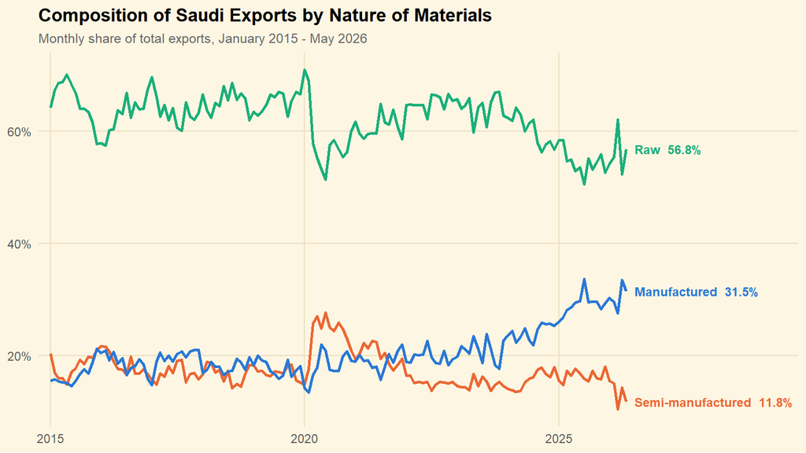

```r
pal = c("Raw"               = "#1baf7a",
        "Semi-manufactured" = "#eb6834",
        "Manufactured"      = "#2a78d6")
ends = monthly[monthly$date == max(monthly$date), ]

ggplot(monthly, aes(date, share, color = cat)) +
  geom_line(linewidth = 0.9) +
  geom_text(data = ends, aes(label = sprintf("%s  %.1f%%", cat, share)),
            hjust = 0, nudge_x = 60, size = 3.2, fontface = "bold",
            show.legend = FALSE) +
  scale_color_manual(values = pal) +
  scale_x_date(expand = expansion(mult = c(0.02, 0.28))) +
  scale_y_continuous(labels = function(x) paste0(x, "%")) +
  labs(title = "Composition of Saudi Exports by Nature of Materials",
       subtitle = "Monthly share of total exports, January 2015 - May 2026",
       x = NULL, y = NULL) +
  theme(legend.position = "none",
        plot.title      = element_text(face = "bold", size = 13),
        plot.subtitle   = element_text(color = "grey40", size = 9.5),
        axis.text       = element_text(color = "grey35"))
```

The chart shows the answer to our first question. The **manufactured** share starts at **15.5%** in January 2015 and ends at **31.5%** in May 2026, while the **raw materials** share moves in the opposite direction. The **semi-manufactured** share changes very little.

Two features of the chart deserve attention:

1. **The movement is not smooth.** All three series fluctuate month to month, and there are sharp reversals in 2017, 2020 and 2023. We come back to these in Section 5.4.
2. **The rise is not constant.** The manufactured share climbs quickly until 2016, stays roughly flat between 2017 and 2020, then rises again and accelerates toward the end of the period.

To put numbers on what the chart shows, we compare the average share in the first full year with the last full year.

## 4.1 Comparing shares: 2015 against 2025

```r
aggregate(share ~ cat + year,
          data = monthly[monthly$year %in% c(2015, 2025), ],
          FUN = mean)
```

| cat | year | share |
| --- | --- | --- |
| Raw | 2015 | 65.39610 |
| Semi-manufactured | 2015 | 18.09415 |
| Manufactured | 2015 | 16.50975 |
| Raw | 2025 | 54.55376 |
| Semi-manufactured | 2025 | 16.38739 |
| Manufactured | 2025 | 29.05885 |

## 4.2 Checking the absolute values

A share can rise for two very different reasons: the numerator grew, or the denominator shrank. The question matters, because only the first is diversification. Writing the manufactured share in full makes the ambiguity explicit:

$$s_{\text{Man},t} = \frac{V_{\text{Man},t}}
{V_{\text{Man},t} + V_{\text{Semi},t} + V_{\text{Raw},t}} \times 100$$

The share rises either when the numerator grows or when $V_{\text{Raw},t}$ falls, and shares alone cannot tell the two apart. The absolute values settle it.

```r
yearly = aggregate(value ~ cat + year, data = monthly, FUN = sum)
yearly[yearly$year %in% c(2015, 2025), ]
```

|  | cat | year | value |
| --- | --- | --- | --- |
| 1 | Raw | 2015 | 501779.2 |
| 2 | Semi-manufactured | 2015 | 136399.7 |
| 3 | Manufactured | 2015 | 124642.2 |
| 31 | Raw | 2025 | 637709.6 |
| 32 | Semi-manufactured | 2025 | 191542.6 |
| 33 | Manufactured | 2025 | 340069.4 |

The absolute figures are decisive, and they are more favourable to the diversification story than the shares alone suggest. Manufactured exports rose from **124.6** to **340.1** billion riyals — a factor of **2.7**, or **10.6%** a year compounded. Crucially, raw material exports did **not** collapse: they grew from **501.8** to **637.7** billion, up **27%** over the decade. Semi-manufactured exports grew **40%**.

All three categories expanded. The manufactured share therefore rose not because oil exports shrank, but because manufacturing grew roughly four times faster than raw materials — **10.6%** a year against **2.4%**. This is the strongest form the result could take: a compositional shift driven entirely by differential growth, with no contraction anywhere in the denominator.

## 4.3 Testing the trend

A rising line in a chart is not evidence on its own. We fit a linear trend and test whether its slope differs from zero:

$$s_t = \beta_0 + \beta_1 t + \varepsilon_t,
\qquad
H_0: \beta_1 = 0
\quad \text{vs} \quad
H_1: \beta_1 \neq 0$$

where $\beta_1$ is the average change in the share per month, in percentage points.

```r
trend_model = lm(share ~ t, data = man)
summary(trend_model)
```

```
##
## Call:
## lm(formula = share ~ t, data = man)
##
## Residuals:
##     Min      1Q  Median      3Q     Max
## -6.5126 -1.9293 -0.1418  1.7969  8.5459
##
## Coefficients:
##              Estimate Std. Error t value Pr(>|t|)
## (Intercept) 15.057682   0.485489   31.02   <2e-16 ***
## t            0.079082   0.006104   12.96   <2e-16 ***
## ---
## Signif. codes:  0 '***' 0.001 '**' 0.01 '*' 0.05 '.' 0.1 ' ' 1
##
## Residual standard error: 2.826 on 135 degrees of freedom
## Multiple R-squared:  0.5542, Adjusted R-squared:  0.5509
## F-statistic: 167.8 on 1 and 135 DF,  p-value: < 2.2e-16
```

The ordinary least squares standard errors above are not trustworthy on their own. In a time series the residuals are **autocorrelated**: a month that sits above the trend line is usually followed by another month above it. OLS treats the observations as independent, so it understates the standard error and overstates significance. The Newey-West estimator corrects for this, leaving the slope estimate unchanged.

```r
coeftest(trend_model, vcov = NeweyWest(trend_model))
```

```
##
## t test of coefficients:
##
##              Estimate Std. Error t value  Pr(>|t|)
## (Intercept) 15.057682   1.552771  9.6973 < 2.2e-16 ***
## t            0.079082   0.026556  2.9780  0.003441 **
## ---
## Signif. codes:  0 '***' 0.001 '**' 0.01 '*' 0.05 '.' 0.1 ' ' 1
```

The slope survives the correction. At **0.079** percentage points a month — **0.95** points a year — the trend remains significant at the 1% level ($p = 0.0034$) even with the standard error widened for autocorrelation. The linear model explains **55%** of the variation in the manufactured share ($R^2 = 0.554$), which is high for a monthly series of this length and confirms that the movement in the chart is a trend rather than drift around a fixed level.

```r
# Slope in percentage points per year
round(coef(trend_model)["t"] * 12, 3)
```

```
##     t
## 0.949
```

# 5. Structure of the Series

```r
man_ts = ts(man$share, start = c(2015, 1), frequency = 12)

length(man_ts)      # 137
```

```
## [1] 137
```

```r
start(man_ts)       # 2015/1
```

```
## [1] 2015    1
```

```r
end(man_ts)         # 2026/5
```

```
## [1] 2026    5
```

```r
frequency(man_ts)   # 12
```

```
## [1] 12
```

## 5.1 STL Decomposition

STL splits the series into three additive components:

$$y_t = T_t + S_t + R_t$$

the trend-cycle, the seasonal component, and the remainder.

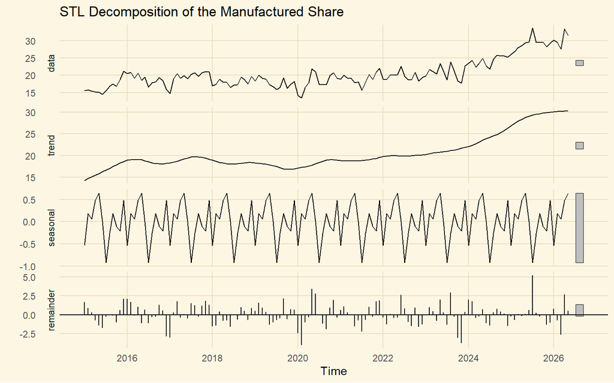

```r
fit = stl(man_ts, s.window = "periodic")

autoplot(fit) +
  labs(title = "STL Decomposition of the Manufactured Share")
```

## 5.2 Strength of Each Component

A common mistake here is to divide each component’s variance by the variance of the series and read the results as percentages. The components are correlated, so those figures do not add to 100 and cannot be interpreted as shares. The standard measure compares each component against the remainder instead, giving a value between 0 and 1:

$$F_T = \max\!\left(0,\, 1 - \frac{\mathrm{Var}(R_t)}{\mathrm{Var}(T_t +
R_t)}\right),
\qquad
F_S = \max\!\left(0,\, 1 - \frac{\mathrm{Var}(R_t)}{\mathrm{Var}(S_t +
R_t)}\right)$$

A value near 1 means the component dominates the noise; a value near 0 means it is indistinguishable from it.

```r
comp = fit$time.series
R    = comp[, "remainder"]
round(c(trend    = max(0, 1 - var(R) / var(comp[, "trend"]    + R)),
        seasonal = max(0, 1 - var(R) / var(comp[, "seasonal"] + R))), 3)
```

```
##    trend seasonal
##    0.883    0.082
```

```r
round(c(seasonal  = diff(range(comp[, "seasonal"])),
        remainder = diff(range(R)),
        data      = diff(range(man_ts))), 2)
```

```
##  seasonal remainder      data
##      1.57      9.26     20.20
```

The decomposition is lopsided. The trend strength is **0.883**, close to the upper bound of 1: almost everything in this series is trend. The seasonal strength is **0.082**, near zero, so the seasonal component is barely distinguishable from noise.

The ranges confirm it. The seasonal component spans only **1.57** percentage points across the whole period, against **9.26** for the remainder and **20.20** for the series itself. Seasonality accounts for less than a tenth of the movement the data actually shows — a finding that shapes the modelling choices in Section 6.

## 5.3 Seasonality Check

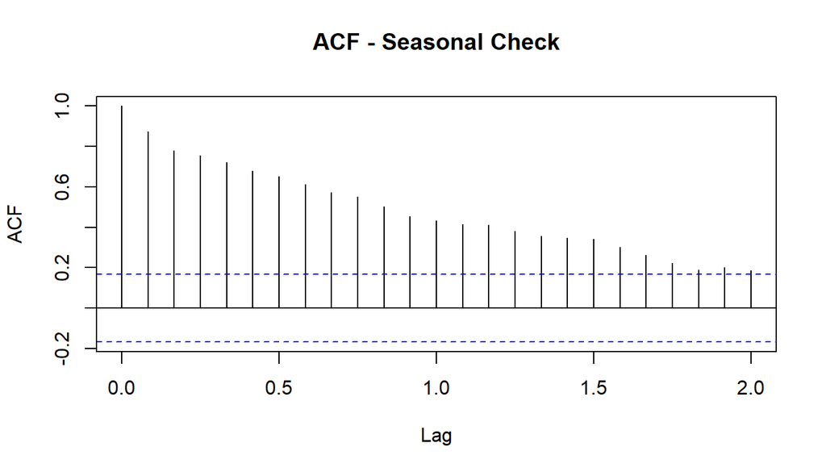

```r
a = acf(man_ts, lag.max = 24, main = "ACF - Seasonal Check")
```

```r
setNames(round(as.numeric(a$acf)[12:14], 3), paste("lag", 11:13))
```

```
## lag 11 lag 12 lag 13
##  0.453  0.431  0.413
```

```r
round(2 / sqrt(length(man_ts)), 3)
```

```
## [1] 0.171
```

There is no annual seasonality. A seasonal series would show an isolated peak at lag 12, standing clear of its neighbours. Instead the three values decline smoothly — **0.453** at lag 11, **0.431** at lag 12, **0.413** at lag 13 — with no peak at all.

All three exceed the significance bound of **0.171**, but that reflects the trend rather than a seasonal cycle: a trending series is correlated with itself at every lag. The gradual decay is the signature of a trend, not of a repeating annual pattern, and it agrees with the seasonal strength of 0.082 found above.

## 5.4 Shock Analysis

```r
idx = order(abs(R), decreasing = TRUE)[1:6]

data.frame(date  = format(man$date[idx], "%Y-%m"),
           shock = round(R[idx], 2))
```

| date | shock |
| --- | --- |
| 2025-07 | 5.22 |
| 2020-02 | -4.04 |
| 2023-11 | -3.78 |
| 2020-05 | 3.45 |
| 2023-10 | -3.11 |
| 2017-01 | -3.07 |

```r
monthly[monthly$date %in% man$date[idx],
        c("date", "cat", "value", "share")]
```

|  | date | cat | value | share |
| --- | --- | --- | --- | --- |
| 73 | 2017-01-01 | Raw | 48493.2 | 69.59544 |
| 74 | 2017-01-01 | Semi-manufactured | 10932.1 | 15.68930 |
| 75 | 2017-01-01 | Manufactured | 10253.4 | 14.71526 |
| 184 | 2020-02-01 | Raw | 43984.7 | 68.93905 |
| 185 | 2020-02-01 | Semi-manufactured | 11237.4 | 17.61284 |
| 186 | 2020-02-01 | Manufactured | 8580.2 | 13.44810 |
| 193 | 2020-05-01 | Raw | 19859.1 | 53.22415 |
| 194 | 2020-05-01 | Semi-manufactured | 9271.5 | 24.84844 |
| 195 | 2020-05-01 | Manufactured | 8181.6 | 21.92741 |
| 316 | 2023-10-01 | Raw | 69536.7 | 66.92418 |
| 317 | 2023-10-01 | Semi-manufactured | 15377.4 | 14.79967 |
| 318 | 2023-10-01 | Manufactured | 18989.6 | 18.27615 |
| 319 | 2023-11-01 | Raw | 63610.3 | 66.98451 |
| 320 | 2023-11-01 | Semi-manufactured | 14558.3 | 15.33055 |
| 321 | 2023-11-01 | Manufactured | 16794.1 | 17.68494 |
| 379 | 2025-07-01 | Raw | 51432.3 | 50.51753 |
| 380 | 2025-07-01 | Semi-manufactured | 16122.3 | 15.83555 |
| 381 | 2025-07-01 | Manufactured | 34256.2 | 33.64692 |

Two of these months make the same point from opposite directions, and together they justify the whole approach of this report.

**July 2025** is the largest positive shock at **+5.22** points. Here the share of 33.6% reflects genuine expansion: manufactured exports reached **34,256** million riyals, their highest value in the entire series, while raw materials at 51,432 million sat near their long-run average. The numerator moved.

**May 2020** is the fourth largest at **+3.45** points — and it means the opposite. Manufactured exports that month were only **8,182** million, close to their minimum for the whole period. The share rose because raw materials collapsed to **19,859** million, their lowest value in eleven years, as oil markets seized during the first months of the pandemic. The denominator moved.

Read from the shares alone, both months look like progress. Read against the absolute values, one is growth and the other is contraction elsewhere. This is precisely the ambiguity set out in Section 4.2, appearing here in two specific months.

The negative shocks share a pattern: February 2020, October and November 2023, and January 2017 are all months when raw materials stood well above their average — between 66.9% and 69.6% of exports — compressing the manufactured share arithmetically.

# 6. Modelling

## 6.1 Stationarity Test

ARIMA requires a stationary series. The Augmented Dickey-Fuller test takes

$$H_0: \text{the series has a unit root (non-stationary)}$$

Note that the null here is the *undesirable* case, the reverse of the usual convention: a **small** $p$-value is the good outcome.

```r
adf.test(man_ts)
```

```
##
##  Augmented Dickey-Fuller Test
##
## data:  man_ts
## Dickey-Fuller = -1.0845, Lag order = 5, p-value = 0.9217
## alternative hypothesis: stationary
```

```r
adf.test(diff(man_ts))
```

```
##
##  Augmented Dickey-Fuller Test
##
## data:  diff(man_ts)
## Dickey-Fuller = -6.2324, Lag order = 5, p-value = 0.01
## alternative hypothesis: stationary
```

The result is unambiguous. On the level the test statistic is **-1.08** with $p = 0.92$: nowhere near rejection, so we cannot rule out a unit root. After first differencing the statistic falls to **-6.23** with $p < 0.01$, comfortably rejecting non-stationarity.

The series is therefore integrated of order one, $d = 1$, and the differenced series is what the model should be built on.

## 6.2 ACF and PACF After Differencing

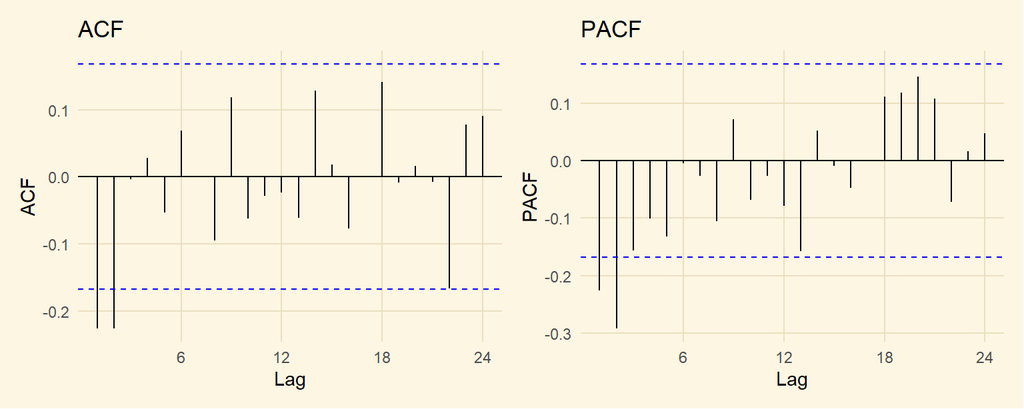

```r
p1 = ggAcf(diff(man_ts),  lag.max = 24) + labs(title = "ACF")
p2 = ggPacf(diff(man_ts), lag.max = 24) + labs(title = "PACF")

p1 | p2
```

The two functions point the same way. The ACF of the differenced series shows significant **negative** autocorrelation at lags 1 and 2, both beyond the confidence bounds, and then falls inside them and stays there. The PACF, by contrast, does not cut off: it starts negative and decays gradually across the early lags.

That combination is the signature of a moving-average process of order two. An $\mathrm{AR}(p)$ process would show the reverse — a PACF cutting off at lag $p$ with a slowly decaying ACF. The reading therefore suggests $\mathrm{ARIMA}(0,1,2)$, and Section 6.3 can be checked against it rather than accepted on trust.

Neither plot shows anything notable at lag 12, which agrees with the seasonality check in Section 5.3. A small number of bars near lags 20 to 23 touch the bounds, but with 24 lags examined at the 5% level one or two such crossings are expected by chance and no isolated lag carries a structural interpretation.

## 6.3 Model Selection

The general model is

$$\phi(B)(1 - B)^d y_t = c + \theta(B)\,\varepsilon_t$$

where $B$ is the backshift operator and $\phi$, $\theta$ are the autoregressive and moving-average polynomials of orders $p$ and $q$. We hold out the last twelve months so the model can later be judged on data it has never seen.

```r
train = window(man_ts, end = c(2025, 5))

fit1 = auto.arima(train)
summary(fit1)
```

```
## Series: train
## ARIMA(0,1,2) with drift
##
## Coefficients:
##           ma1      ma2   drift
##       -0.3331  -0.3176  0.1003
## s.e.   0.0842   0.0836  0.0523
##
## sigma^2 = 2.691:  log likelihood = -236.04
## AIC=480.08   AICc=480.41   BIC=491.36
##
## Training set error measures:
##                       ME     RMSE      MAE        MPE     MAPE      MASE
## Training set 0.001265086 1.613859 1.309565 -0.7129301 6.834207 0.5231028
##                     ACF1
## Training set 0.008913902
```

## 6.4 Comparing Alternatives

AIC is only comparable across models fitted to the **same** differenced series. If `auto.arima` selected a different order of differencing, or added a seasonal part, the comparison below is meaningless. So we check the order first.

```r
setNames(fit1$arma, c("p", "q", "P", "Q", "period", "d", "D"))
```

```
##      p      q      P      Q period      d      D
##      0      2      0      0     12      1      0
```

```r
stopifnot(fit1$arma[6] == 1, fit1$arma[3] == 0, fit1$arma[4] == 0)

fit2 = Arima(train, order = c(2, 1, 0))
fit3 = Arima(train, order = c(2, 1, 2))

round(c(auto = fit1$aic, ar2 = fit2$aic, both = fit3$aic), 2)
```

```
##   auto    ar2   both
## 480.08 486.24 484.99
```

The automatic selection wins clearly. ARIMA(0,1,2) with drift scores **480.08**, against **484.99** for ARIMA(2,1,2) and **486.24** for ARIMA(2,1,0). A gap of five to six AIC points is substantial. The agreement matters as much as the ranking: the specification chosen by AICc is the same one the correlation plots pointed to, so two independent routes — visual identification and automatic search — converge on the same model.

# 7. Validation

## 7.1 Out-of-Sample Accuracy

With $e_t$ the forecast errors over the $h = 12$ held-out months,

$$\mathrm{MASE} =
\frac{\frac{1}{h}\sum |e_t|}
{\frac{1}{n-1}\sum_{t=2}^{n} |y_t - y_{t-1}|}$$

The denominator is the error of a naive forecast $\hat{y}_t = y_{t-1}$, so $\mathrm{MASE} < 1$ means the model beats carrying the last value forward. The **Test set** row is the one that matters.

```r
test = window(man_ts, start = c(2025, 6))   # 12 months the model never saw

fc = forecast(fit1, h = 12)

round(accuracy(fc, test), 3)
```

```
##                 ME  RMSE   MAE    MPE  MAPE  MASE   ACF1 Theil's U
## Training set 0.001 1.614 1.310 -0.713 6.834 0.523  0.009        NA
## Test set     1.551 2.361 1.809  4.834 5.767 0.723 -0.110     0.916
```

The model forecasts better than the benchmark. On the twelve held-out months the MASE is **0.723**, meaning the average error is about 72% of what a naive “carry the last value forward” forecast would produce. Theil’s U of **0.916** points the same way. The mean absolute percentage error is **5.8%**.

One feature deserves attention. The mean error on the test set is **+1.55**, and a positive mean error means the model **under-forecast** the manufactured share in those months: the rise through late 2025 and early 2026 was faster than the fitted drift anticipated. The gap between the training MASE of 0.523 and the test MASE of 0.723 is the expected cost of forecasting genuinely unseen data, and the size of that gap is modest.

## 7.2 Residual Diagnostics

If the model has captured the structure of the series, nothing predictable should remain in the residuals. The Ljung-Box test takes independence as its null, so here a **large** $p$-value is the good result.

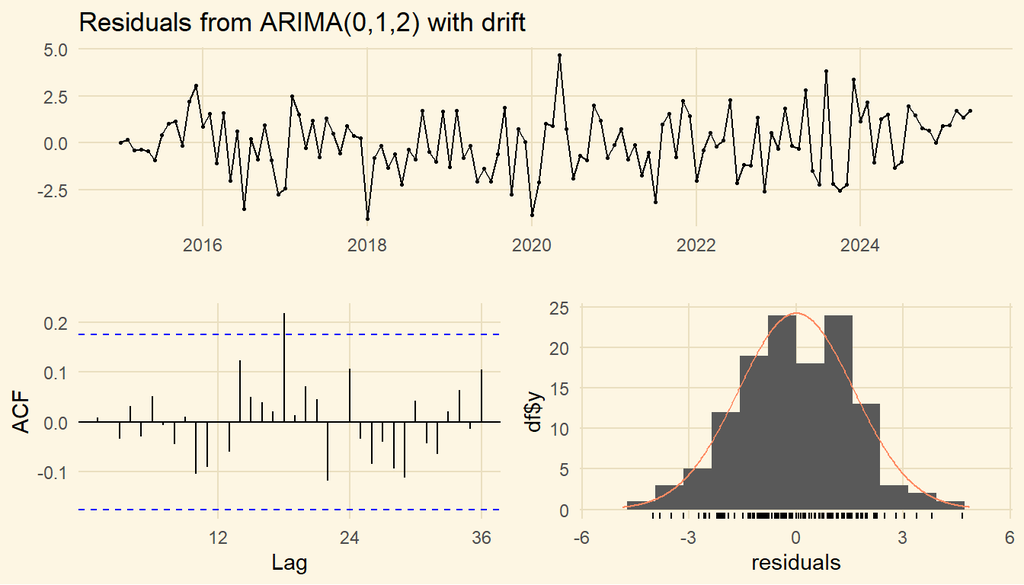

```
##
##  Ljung-Box test
##
## data:  Residuals from ARIMA(0,1,2) with drift
## Q* = 19.087, df = 22, p-value = 0.64
##
## Model df: 2.   Total lags used: 24
```

```r
checkresiduals(fit1)
```

The residuals pass. The Ljung-Box statistic over 24 lags is **19.09** on 22 degrees of freedom, giving $p = 0.64$ — far from rejection. There is no evidence of remaining autocorrelation, the residual plot shows no systematic pattern, and the histogram is approximately normal.

This does not prove the model is correct; a test that fails to reject is not a test that confirms. What it does establish is that no obvious structure has been left unmodelled.

# 8. Forecast

## 8.1 Final Model

```r
fit_final = auto.arima(man_ts)
summary(fit_final)
```

```
## Series: man_ts
## ARIMA(0,1,2) with drift
##
## Coefficients:
##           ma1      ma2   drift
##       -0.3750  -0.2738  0.1125
## s.e.   0.0822   0.0823  0.0518
##
## sigma^2 = 2.907:  log likelihood = -264.26
## AIC=536.51   AICc=536.82   BIC=548.16
##
## Training set error measures:
##                        ME     RMSE      MAE        MPE     MAPE      MASE
## Training set 0.0001843548 1.679914 1.340512 -0.7503559 6.723572 0.5001063
##                      ACF1
## Training set -0.001845828
```

Refitting on all 137 observations selects **the same specification** as the model validated in Section 7 — ARIMA(0,1,2) with drift — so the out-of-sample performance reported there applies directly to the model used for forecasting. The coefficients shift slightly with the extra year of data, and the drift term strengthens from 0.100 to **0.1125** percentage points a month, now significant at the 5% level. The recent months have reinforced the upward trend rather than tempering it.

## 8.2 Forecast to 2030

The horizon runs from June 2026 to December 2030, $h = 55$ months. Prediction intervals take the form

$$\hat{y}_{T+h} \pm z_{1-\alpha/2}\,\hat{\sigma}_h,
\qquad \hat{\sigma}_h \propto \sqrt{h}$$

which is why the band widens as it moves right rather than staying parallel.

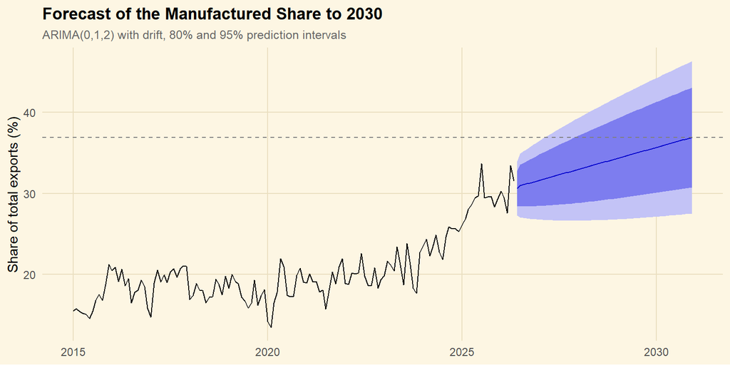

```r
fc_2030 = forecast(fit_final, h = 55)

autoplot(fc_2030) +
  geom_hline(yintercept = tail(fc_2030$mean, 1),
             linetype = "dashed", color = "grey50", linewidth = 0.4) +
  labs(title = "Forecast of the Manufactured Share to 2030",
       subtitle = paste0(as.character(fit_final),
                         ", 80% and 95% prediction intervals"),
       x = NULL, y = "Share of total exports (%)") +
  theme(plot.title    = element_text(face = "bold", size = 13),
        plot.subtitle = element_text(color = "grey40", size = 9.5))
```

```r
round(c(forecast = tail(fc_2030$mean, 1),
        lower95  = tail(fc_2030$lower[, 2], 1),
        upper95  = tail(fc_2030$upper[, 2], 1)), 2)
```

```
## forecast  lower95  upper95
##    36.92    27.51    46.33
```

By December 2030 the model places the manufactured share at **36.9%**, with a 95% prediction interval running from **27.5%** to **46.3%**. The width of that interval is itself part of the result, and Section 10 explains why it should not be read as a precise target.

# 9. Summary

> **The composition has shifted.** Manufactured goods made up **15%** of Saudi exports at the start of 2015 and **31%** by mid-2026. Every category grew in absolute terms over the decade — oil exports included — but manufactured exports grew more than four times faster than raw materials, and that difference is what moved the structure.

## 9.1 The three categories

| Category | Share in 2015 | Share in 2025 | Change | Growth in value, a year |
| --- | --- | --- | --- | --- |
| Raw | 65.4% | 54.6% | -10.8 points | +2.4% |
| Semi-manufactured | 18.1% | 16.4% | -1.7 points | +3.5% |
| Manufactured | 16.5% | 29.1% | +12.5 points | +10.6% |

The last column is the one that settles the question. A share can rise simply because something else fell, but this column measures each category against its own past, in riyals. Manufactured exports grew on their own terms.

## 9.2 The figures at a glance

|  | Value |
| --- | --- |
| Period covered | January 2015 to May 2026 |
| Total exports over the period | 11.6 trillion riyals |
| Average exports a year | 1.02 trillion riyals |
| Manufactured share, start | 15.5% |
| Manufactured share, latest | 31.5% |
| Change over the period | +16.0 points |
| Average change a year | +0.95 points |
| Projected share by December 2030 | 36.9% |
| Range the projection could fall in | 28% to 46% |

The last row deserves emphasis. The projection is a direction, not a target: the range around it is wide because four and a half years is a long way to look ahead from eleven years of data.

# 10. Limitations

Four constraints affect how the results above should be read.

1. **Shares are not independent.** The adding-up constraint implies

   $$\sum_i \Delta s_{i,t} = 0$$

   so the three series cannot move freely. A rise in the manufactured share is arithmetically identical to a fall in the sum of the other two. This is why Section 4.2 checks the absolute values: it is the only part of the analysis that can distinguish real growth in manufacturing from a mechanical effect of falling oil exports.
2. **The forecast horizon is long relative to the data.** We project 55 months forward from 137 observations. Prediction intervals widen with the square root of the horizon, which is why the 2030 interval is so much wider than the 2027 one. The central forecast is a continuation of the estimated drift, not a prediction of policy.
3. **The model can leave the admissible range.** A share is bounded between 0 and 100, but an ARIMA model with drift extrapolates linearly and knows nothing about that bound. In this case the upper 95% limit reaches 46.3% and the problem does not bind, but that is a property of these particular numbers rather than of the method. Modelling

   $$z_t = \log\!\left(\frac{s_t}{100 - s_t}\right)$$

   and inverting afterwards would respect the bound by construction, at any horizon. We did not apply it here because the raw limits remained plausible.
4. **Structural breaks are treated as noise.** The shocks identified in Section 5.4 — the 2020 collapse in particular — are absorbed into the remainder rather than modelled. A model that allowed the trend to change slope after 2020 might fit the recent years better, at the cost of relying on a break date chosen after seeing the data.

# 11. Conclusion

The question was whether the composition of Saudi exports has shifted from raw materials toward manufactured goods between 2015 and 2026. The evidence points in one direction, with qualifications.

The manufactured share rose from **15.5%** (January 2015) to **31.5%** (May 2026), an average of **0.95** percentage points a year. The trend remains statistically significant after correcting the standard errors for autocorrelation, so it is not a by-product of month-to-month noise.

Section 4.2 shows there was no denominator effect at all. Raw material exports grew 27% over the decade and semi-manufactured exports 40%, while manufactured exports grew 173% — a compound rate of 10.6% a year against 2.4% for raw materials. The shift in composition came entirely from differential growth, not from contraction anywhere.

Extending the fitted model to 2030 gives a central estimate of **36.9%**. The prediction interval is wide, and the limitations in Section 10 explain why: the horizon is long, the model is unaware that a share is bounded, and the 2020 break is absorbed rather than modelled. The direction of the result is firmer than its magnitude.

# 12. Technical Appendix

The figures below are for readers who want to check the statistical basis of the results. Each is explained in the section it came from.

| Quantity | Value | Section |
| --- | --- | --- |
| Observations | 137 months x 3 categories | 2 |
| Trend slope (percentage points per year) | +0.949 | 4.3 |
| Trend p-value, Newey-West corrected | 0.00344 | 4.3 |
| Trend strength, F_T | 0.883 | 5.2 |
| Seasonal strength, F_S | 0.082 | 5.2 |
| Selected model | ARIMA(0,1,2) with drift | 8.1 |
| Out-of-sample MASE (12 months held out) | 0.723 | 7.1 |
| Ljung-Box p-value, 24 lags | 0.640 | 7.2 |
| Forecast horizon | 55 months | 8.2 |

# 13. References

General Authority for Statistics (GASTAT). *International Trade Statistics — Exports by Nature of Materials*, monthly series, January 2015 – May 2026. Statistical Database. **Accessed 17 September 2026.**